# Process_notebook

Ryan Thomas & Michael Dara

7/6/2021

We must load all the data and packages into R

## Abstract

Basketball as a whole has seen a shift in the way the game is played. It is perceived as having the ability to play fast, and shooting threes on offense is a major key to having a successful offense in this day and age. This trend is very noticeable in the professional level, but one can wonder how this style has affected the play in the NCAA. By looking at data collected from 2013-2019 from teams of each of the major 6 conferences in the NCAA, we will look at how their tempo of play and 3 point shooting affected their win totals and overall finishes in the March Madness tournament. From this, our group created several graphics in an attempt to answer questions related to the data collected, in the hopes of bringing light to the effect that three point shooting and tempo can have on an NCAA game.

## Overview and Motivation

The plan for this project is to see the effect that 3 point shooting and faster tempo can have on achievement in the 6 major conferences of Division 1 NCAA Men’s basketball. The motivation behind this is the change of style in basketball, primarily from the NBA. Is it a good form of team building, should scouts be looking for players they can mold into so they can fit this more fast-paced and 3 point shooting orientated system?

## Related Work

Professional basketball over the last few years has seen a big style shift in the way the games have been played, as we read in the WSJ article: https://www.wsj.com/articles/nba-3-point-revolution-11611190418. The NBA has seen a change in the amount of 3 pointers shot and the overall tempo the games have been played at. This more run and gun “European Style” of basketball was pioneered in the NBA by the Houston Rockets, but has spread across the whole NBA. The era of running your offense mainly through your power-foward or center with his back to the basket in a slow paced half court setting was over. NBA teams began looking for players with a more well rounded game, more specifically, they wanted all 5 players on the floor to be able to shoot 3 pointers at an at least acceptable efficiency, while also contributing to other aspects of the game. This development in the professional leagues develops an obvious question, how is this affecting the college game? NCAA Men’s basketball has several key rules difference as well as strategic differences when compared to the NBA. For one, the NCAA has a longer duration shotclock (30 seconds), than the NBA’s(24 seconds), for those who don’t know, the shotclock is the maximum amount of time the team has to attempt to shoot the ball and it resets once the ball hits the rim or possession of the ball is changed. Another major difference in rules is that the 3 point line is closer to the rim in the NCAA than in the NBA, which makes it easier for players to hit 3 pointers in the NCAA. And one key strategic difference in the NCAA than the NBA is the difference in talent when looking at team to team. These rule differences definitely have an effect on how the game is played. However, the NCAA game almost always is heavily influenced by the way NBA teams are playing. So, we would expect a shift into a similar style of play. This shift in style in the NBA is what made us curious is there a similar shift in the NCAA, and how effective is it?

## Exploratory Data Analysis

#### Question 1

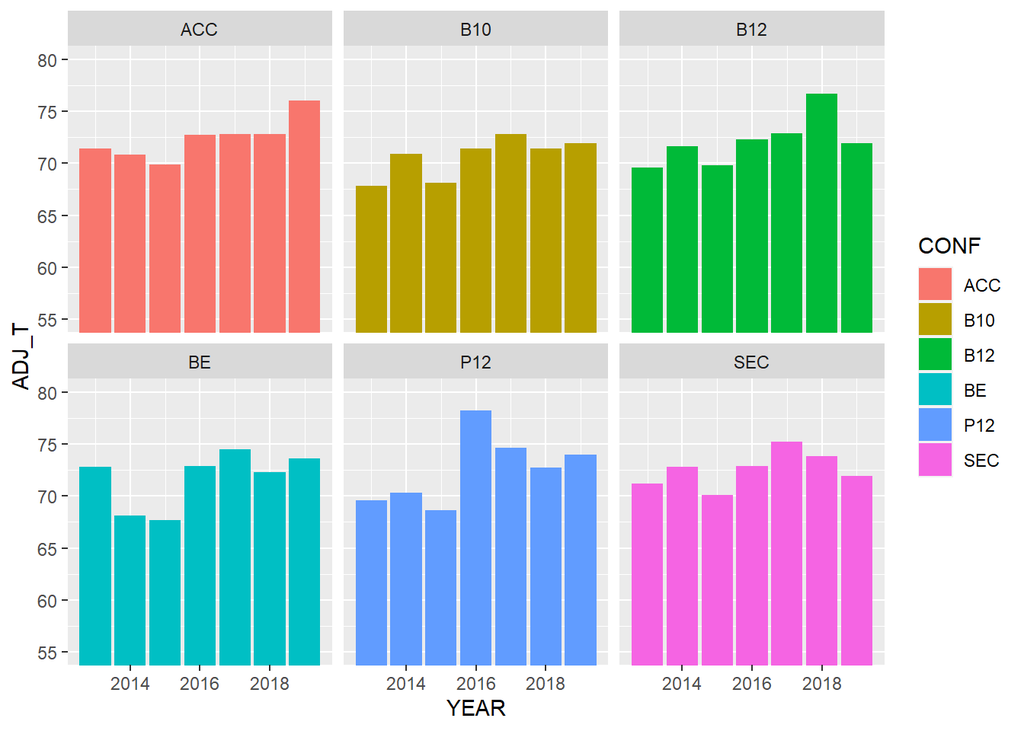

For question 1, we created a bar chart where the year was the x value and y is the Adjusted tempo, and then the data was faceted by Conference. The bar chart does a good job of showing how the tempo has changed over time. The reason it was chosen is because of the type of data we had we could not use a scatterplot with year. The reason we decided to facet by conference was to show how each conference has changed over time since each conference tends to have a different style of play it was only fair to split it by conference. From this we saw that most conferences saw a somewhat increasing amount of tempo over time.

#### Question 2

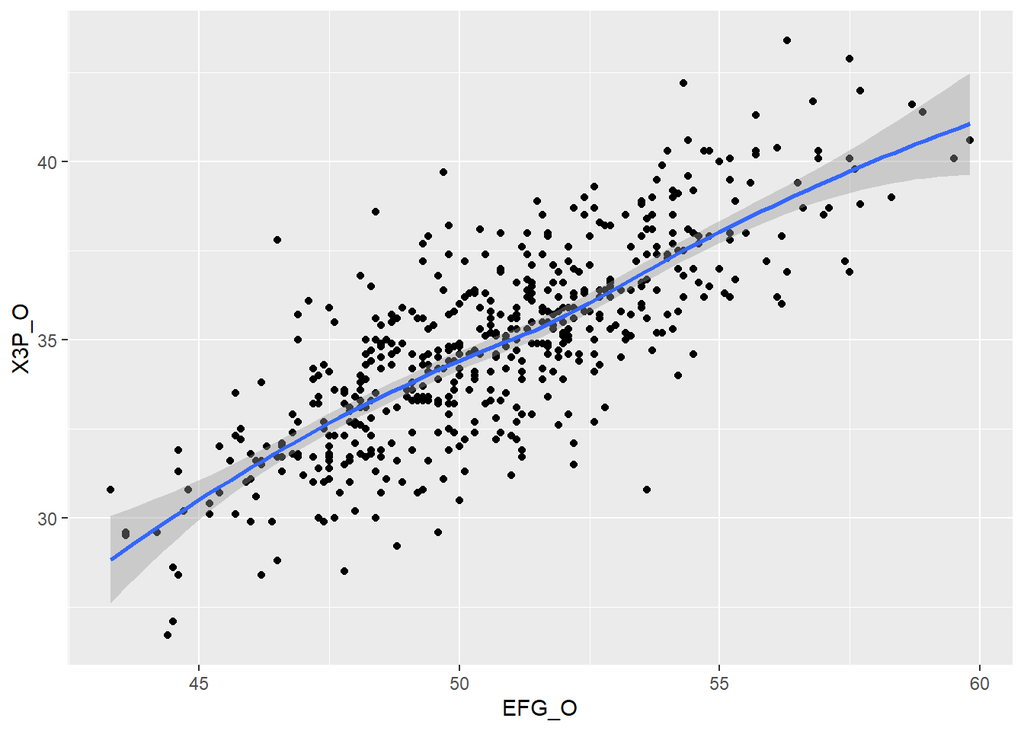

For #2, we created a scatter plot to answer the question of how 3-point% affected effective field-goal%, and we found a positive linear relationship between the two variables. We used a scatter plot as it did the best job of showing the relationship between these two variables. This data was useful in establishing the importance of 3-point% on the offense’s efficiency.

#### Question 3

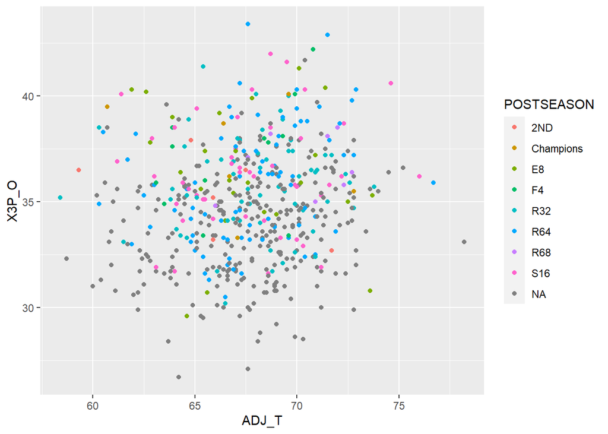

For #3, we created a scatterplot where the x axis corresponded to the adjusted tempo, the y axis was corresponding to the 3-point%, and used color to represent the results of the teams march madness finish. This information was important to displaying the importance of 3-point shooting and tempo and the graph from this was actually chosen to be directly used in our blog post. We can conclude that there is a weakly positive association between 3-point% and adjusted tempo. From this, we also see that it seemed that 3-point% had more of an effect on the teams post season success than adjusted tempo. This was concluded because of how there was still colors resulting in some form of post season success in the higher 3-point % area (over 35%), regardless of tempo. But having a combination of both tempo and a high 3 point % lead to even more post season success.

#### Question 4

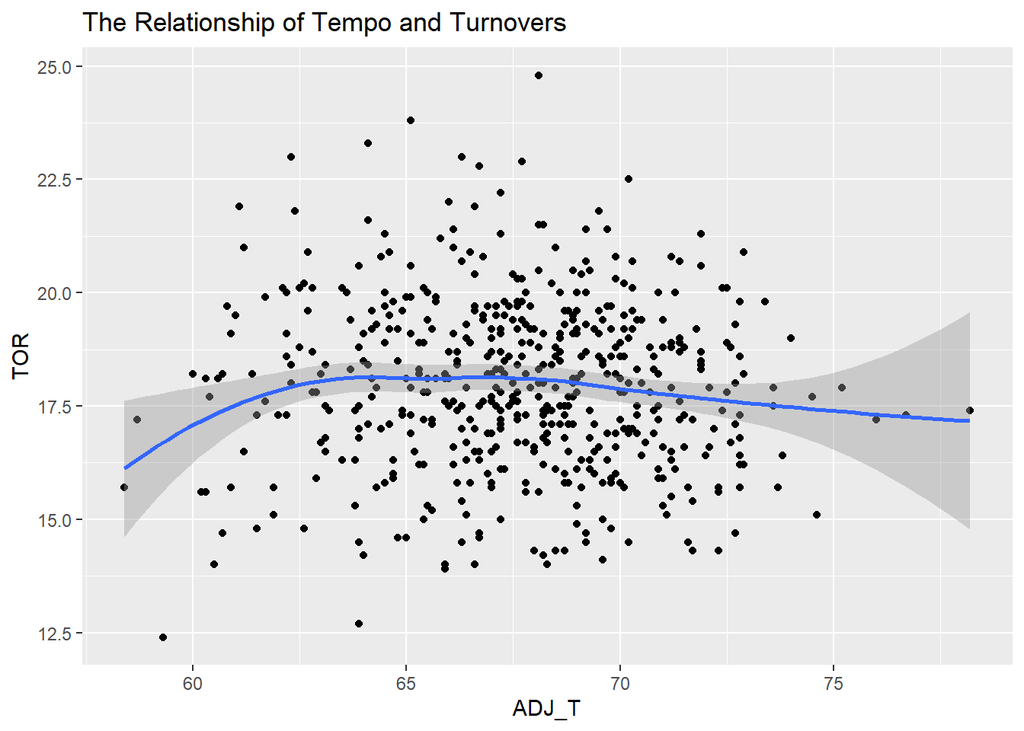

This next graph was also very important to the dataset because it was able to disprove a counterclaim to playing with a higher tempo. From this scatterplot, we see that there is no relationship between tempo and turnovers, as the data seems to be randomly spread out around the graph. This is useful in showing that playing fast will not necessarily lead to more turnovers if done properly. Other factors such as poor coaching or low skilled players can be to blame for the amount of turnovers seen from some of the high tempo teams.

#### Question 5

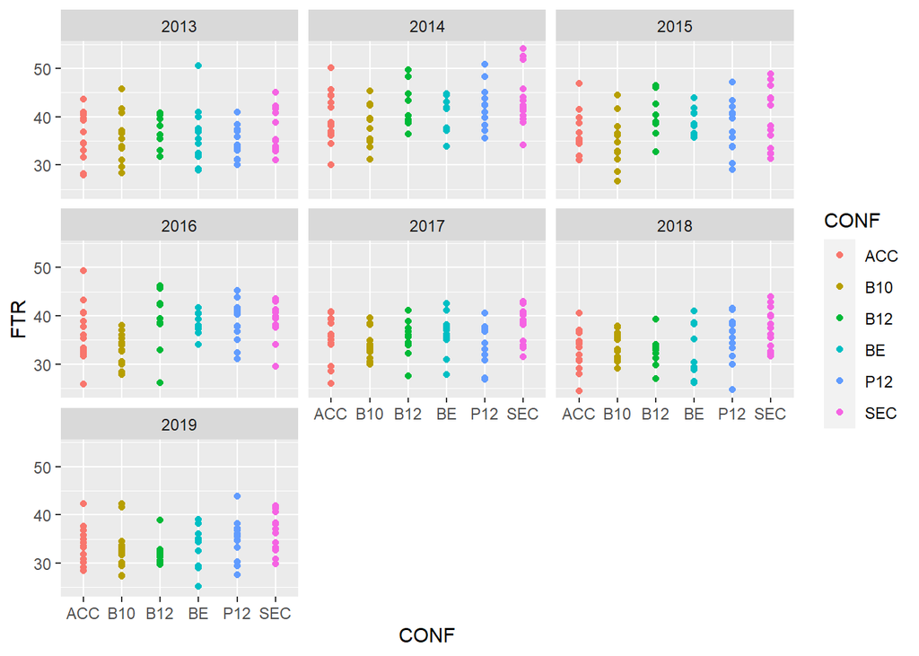

This scatter plot helped display how each conferences free-throw rate changed over time, in hopes to tying it into how an increase in tempo lead to more free throws, but the data shows otherwise. We see that free throw rates have actually decreased over time which upon further analysis makes sense because of an increase in three pointers attempted. In basketball most fouls take place very close to the basket it is less frequent that you see fouls being called out by the three point line. so with an increase in 3 pointers, we can see why there is a decrease in freethrows. In addition, the slight increase in tempo accounts for less time holding the ball, which gives the referees less time to call fouls.

#### Question 6

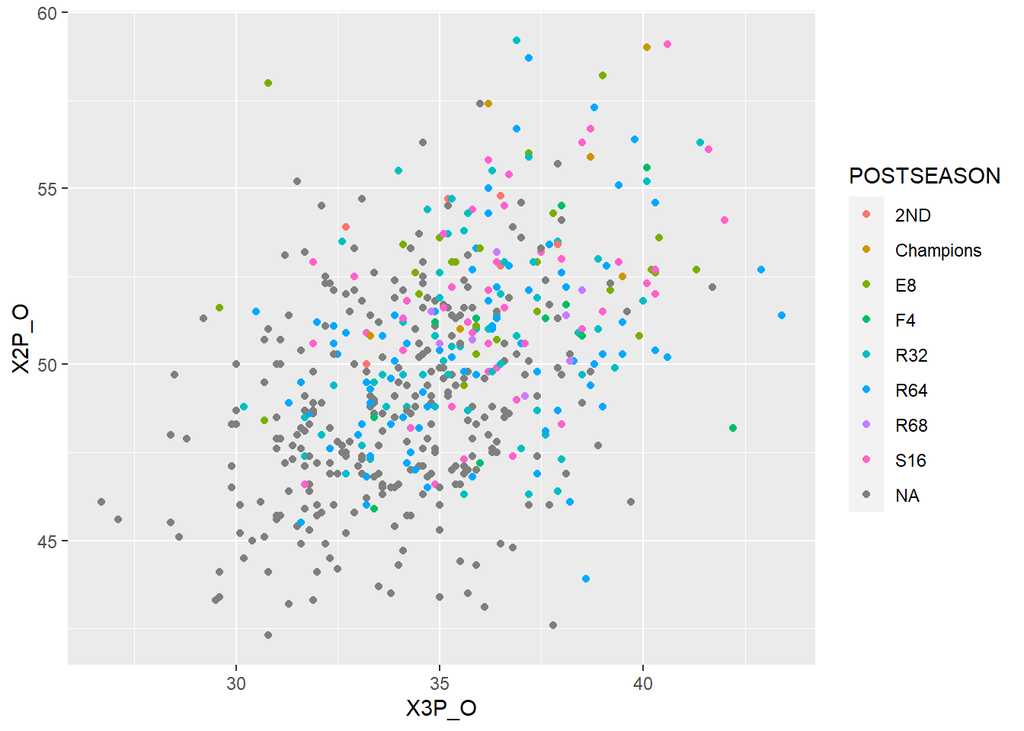

This data set was used to display a relationship between 3 point and 2 point percentages on post season achievement. There is a a positive linear relationship between 3 point and 2 point percentages represented in the scatterplot. We see thanks to the colors that for the most part, shooting better from 3 point is going to lead to slightly more post season success then just shooting well from 2. But being able to shoot well form both ranges lead to the greatest team success.

#### Question 7

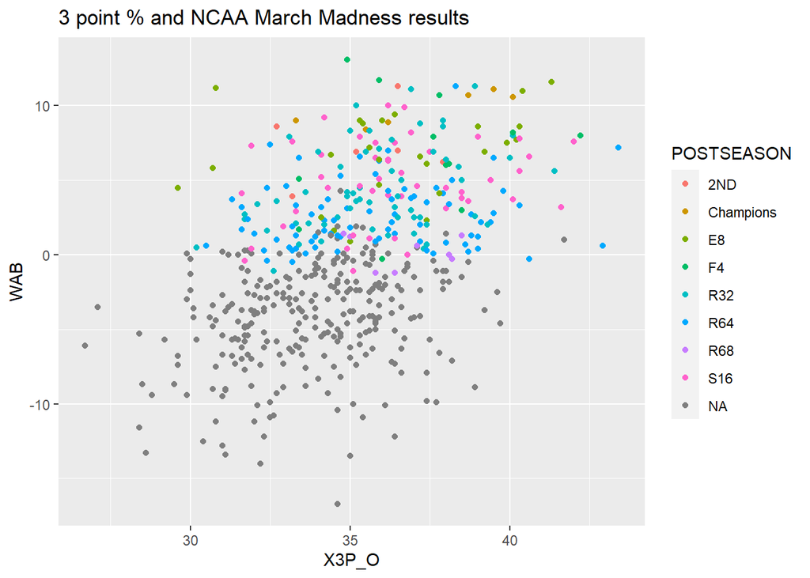

We created a scatterplot where we compared the x-axis of 3 point percentage on the y-axis of wins above the bubble(WAB), and then use color again to represent post season success. We see from this graph that there is a positive linear relationship between WAB and 3-point%, displaying that many of the good 3 point shooting teams win a lot more games then those who do not shoot as well from three. Then wee see that most of these teams also ended up going on to have pretty good post season success which we see represented by the different colors.

#### Question 8

```
##
## Call:
## lm(formula = W ~ X3P_O + ADJ_T, data = cbb)
##
## Residuals:
##      Min       1Q   Median       3Q      Max
## -15.2192  -3.6982   0.0014   3.7344  17.0982
##
## Coefficients:
##             Estimate Std. Error t value Pr(>|t|)
## (Intercept) -6.41777    5.63224  -1.139   0.2550
## X3P_O        1.08418    0.08793  12.330   <2e-16 ***
## ADJ_T       -0.16404    0.07565  -2.168   0.0306 *
## ---
## Signif. codes:  0 '***' 0.001 '**' 0.01 '*' 0.05 '.' 0.1 ' ' 1
##
## Residual standard error: 5.48 on 520 degrees of freedom
## Multiple R-squared:  0.2267, Adjusted R-squared:  0.2237
## F-statistic: 76.22 on 2 and 520 DF,  p-value: < 2.2e-16
```

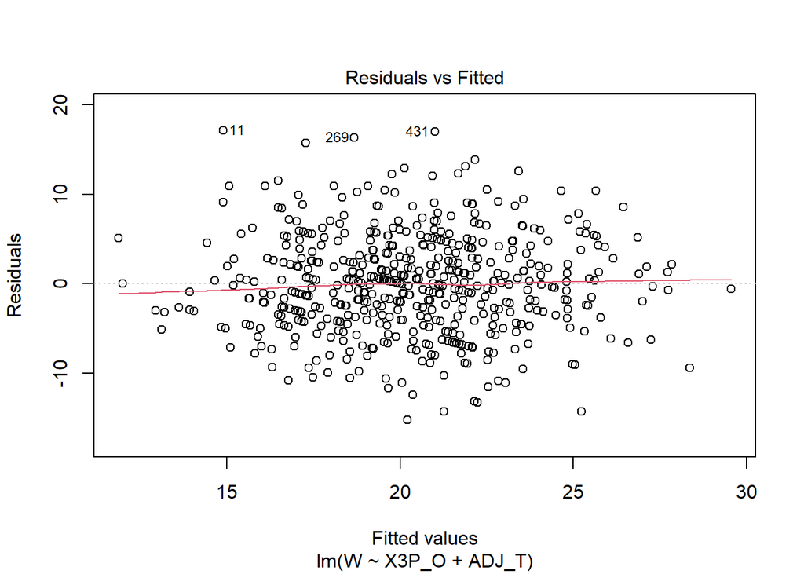

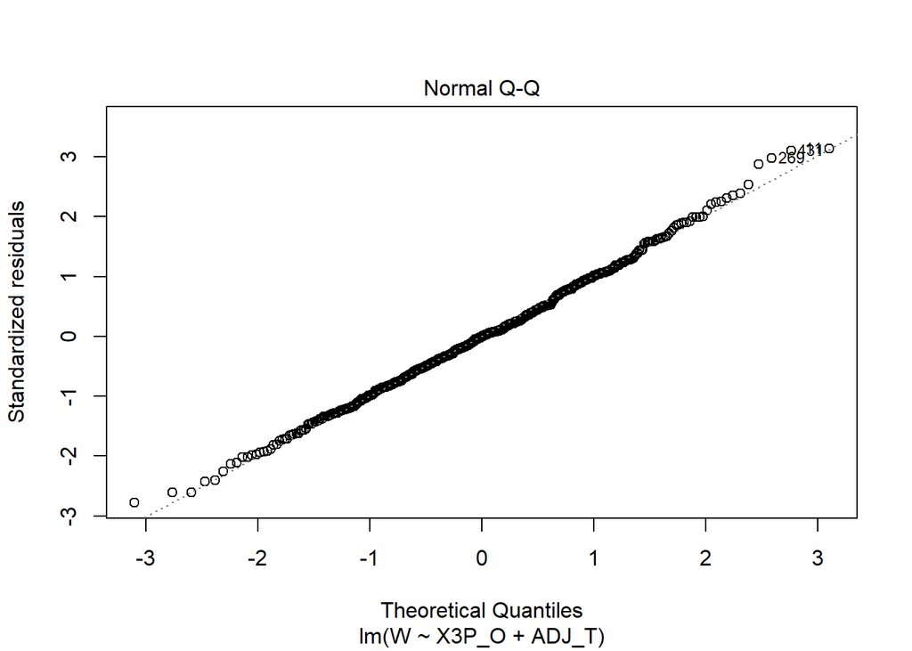

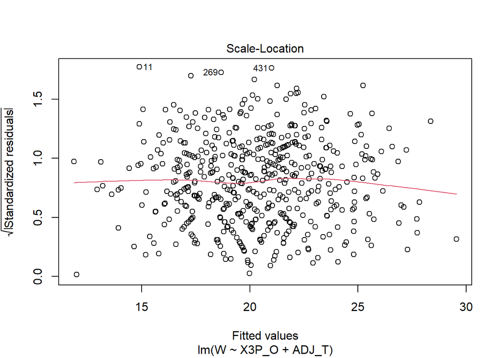

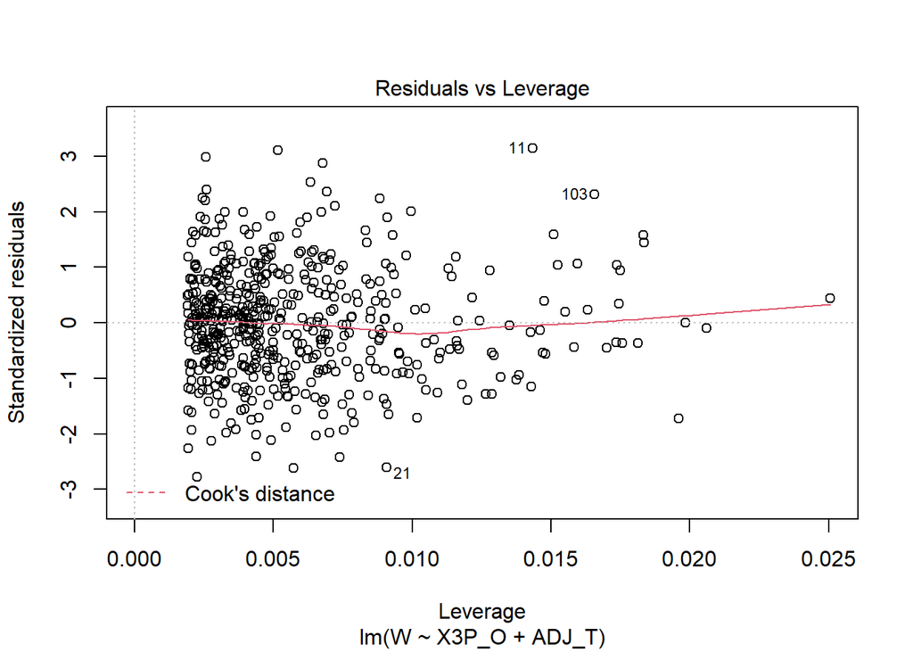